# Grocery Store Marketing Analysis

Author

Pete Woo

This dataset comes from a ficticious grocery store by an owner names Gerry. Gerry is investigating a potential promotion and also wants to identify ways to improve his sales/marketing strategy. They offer a membership that results in 20% off all items for a monthly fee of $999. However, they are offering a discounted membership price of $499. They want insight on their customer behavioral data and to find out which customers are the best options to target for this promotion.

This project will consist of Exploratory Data Analysis, Inferential Analysis, Customer Segmentation, and lastly Predictive Analysis.

```python
import pandas as pd
import numpy as np
from plotnine import ggplot, aes, geom_histogram, geom_bar

%matplotlib inline
```

# Reading In The Data

```python
df = pd.read_csv("superstore_data.csv")
df.head()
```

|  | Id | Year_Birth | Education | Marital_Status | Income | Kidhome | Teenhome | Dt_Customer | Recency | MntWines | MntFruits | MntMeatProducts | MntFishProducts | MntSweetProducts | MntGoldProds | NumDealsPurchases | NumWebPurchases | NumCatalogPurchases | NumStorePurchases | NumWebVisitsMonth | Response | Complain |
| --- | --- | --- | --- | --- | --- | --- | --- | --- | --- | --- | --- | --- | --- | --- | --- | --- | --- | --- | --- | --- | --- | --- |
| 0 | 1826 | 1970 | Graduation | Divorced | 84835.0 | 0 | 0 | 6/16/2014 | 0 | 189 | 104 | 379 | 111 | 189 | 218 | 1 | 4 | 4 | 6 | 1 | 1 | 0 |
| 1 | 1 | 1961 | Graduation | Single | 57091.0 | 0 | 0 | 6/15/2014 | 0 | 464 | 5 | 64 | 7 | 0 | 37 | 1 | 7 | 3 | 7 | 5 | 1 | 0 |
| 2 | 10476 | 1958 | Graduation | Married | 67267.0 | 0 | 1 | 5/13/2014 | 0 | 134 | 11 | 59 | 15 | 2 | 30 | 1 | 3 | 2 | 5 | 2 | 0 | 0 |
| 3 | 1386 | 1967 | Graduation | Together | 32474.0 | 1 | 1 | 11/5/2014 | 0 | 10 | 0 | 1 | 0 | 0 | 0 | 1 | 1 | 0 | 2 | 7 | 0 | 0 |
| 4 | 5371 | 1989 | Graduation | Single | 21474.0 | 1 | 0 | 8/4/2014 | 0 | 6 | 16 | 24 | 11 | 0 | 34 | 2 | 3 | 1 | 2 | 7 | 1 | 0 |

# Cleaning/Manipulating Data

## Displaying Variable Data Types

```python
df.dtypes
```

```
Id                       int64
Year_Birth               int64
Education               object
Marital_Status          object
Income                 float64
Kidhome                  int64
Teenhome                 int64
Dt_Customer             object
Recency                  int64
MntWines                 int64
MntFruits                int64
MntMeatProducts          int64
MntFishProducts          int64
MntSweetProducts         int64
MntGoldProds             int64
NumDealsPurchases        int64
NumWebPurchases          int64
NumCatalogPurchases      int64
NumStorePurchases        int64
NumWebVisitsMonth        int64
Response                 int64
Complain                 int64
dtype: object
```

## Summary Statistics

```python
df.describe().round()
```

|  | Id | Year_Birth | Income | Kidhome | Teenhome | Recency | MntWines | MntFruits | MntMeatProducts | MntFishProducts | MntSweetProducts | MntGoldProds | NumDealsPurchases | NumWebPurchases | NumCatalogPurchases | NumStorePurchases | NumWebVisitsMonth | Response | Complain |
| --- | --- | --- | --- | --- | --- | --- | --- | --- | --- | --- | --- | --- | --- | --- | --- | --- | --- | --- | --- |
| count | 2240.0 | 2240.0 | 2216.0 | 2240.0 | 2240.0 | 2240.0 | 2240.0 | 2240.0 | 2240.0 | 2240.0 | 2240.0 | 2240.0 | 2240.0 | 2240.0 | 2240.0 | 2240.0 | 2240.0 | 2240.0 | 2240.0 |
| mean | 5592.0 | 1969.0 | 52247.0 | 0.0 | 1.0 | 49.0 | 304.0 | 26.0 | 167.0 | 38.0 | 27.0 | 44.0 | 2.0 | 4.0 | 3.0 | 6.0 | 5.0 | 0.0 | 0.0 |
| std | 3247.0 | 12.0 | 25173.0 | 1.0 | 1.0 | 29.0 | 337.0 | 40.0 | 226.0 | 55.0 | 41.0 | 52.0 | 2.0 | 3.0 | 3.0 | 3.0 | 2.0 | 0.0 | 0.0 |
| min | 0.0 | 1893.0 | 1730.0 | 0.0 | 0.0 | 0.0 | 0.0 | 0.0 | 0.0 | 0.0 | 0.0 | 0.0 | 0.0 | 0.0 | 0.0 | 0.0 | 0.0 | 0.0 | 0.0 |
| 25% | 2828.0 | 1959.0 | 35303.0 | 0.0 | 0.0 | 24.0 | 24.0 | 1.0 | 16.0 | 3.0 | 1.0 | 9.0 | 1.0 | 2.0 | 0.0 | 3.0 | 3.0 | 0.0 | 0.0 |
| 50% | 5458.0 | 1970.0 | 51382.0 | 0.0 | 0.0 | 49.0 | 174.0 | 8.0 | 67.0 | 12.0 | 8.0 | 24.0 | 2.0 | 4.0 | 2.0 | 5.0 | 6.0 | 0.0 | 0.0 |
| 75% | 8428.0 | 1977.0 | 68522.0 | 1.0 | 1.0 | 74.0 | 504.0 | 33.0 | 232.0 | 50.0 | 33.0 | 56.0 | 3.0 | 6.0 | 4.0 | 8.0 | 7.0 | 0.0 | 0.0 |
| max | 11191.0 | 1996.0 | 666666.0 | 2.0 | 2.0 | 99.0 | 1493.0 | 199.0 | 1725.0 | 259.0 | 263.0 | 362.0 | 15.0 | 27.0 | 28.0 | 13.0 | 20.0 | 1.0 | 1.0 |

## Creating Age Column from Year_Birth

```python
df["Age"] = 2024 - df["Year_Birth"]
df["Age"].head()
```

```
0    54
1    63
2    66
3    57
4    35
Name: Age, dtype: int64
```

## Creating Days of Customer Column from Dt_Customer

```python
from datetime import date

df['Dt_Customer'] = pd.to_datetime(df['Dt_Customer'], format='%m/%d/%Y')
df["Days_Customer"] = (pd.Timestamp.today() - df["Dt_Customer"]).dt.days
df["Days_Customer"].head()
```

```
0    3767
1    3768
2    3801
3    3625
4    3718
Name: Days_Customer, dtype: int64
```

## Checking For Missing Values

```python
df.isna().sum()
```

```
Id                      0
Year_Birth              0
Education               0
Marital_Status          0
Income                 24
Kidhome                 0
Teenhome                0
Dt_Customer             0
Recency                 0
MntWines                0
MntFruits               0
MntMeatProducts         0
MntFishProducts         0
MntSweetProducts        0
MntGoldProds            0
NumDealsPurchases       0
NumWebPurchases         0
NumCatalogPurchases     0
NumStorePurchases       0
NumWebVisitsMonth       0
Response                0
Complain                0
Age                     0
Days_Customer           0
dtype: int64
```

There are 24 Null values of Income.

## Displaying Rows with NA Values of Income

```python
na_income_indices = df[df["Income"].isna()].index
df[df["Income"].isna()].head()
```

|  | Id | Year_Birth | Education | Marital_Status | Income | Kidhome | Teenhome | Dt_Customer | Recency | MntWines | MntFruits | MntMeatProducts | MntFishProducts | MntSweetProducts | MntGoldProds | NumDealsPurchases | NumWebPurchases | NumCatalogPurchases | NumStorePurchases | NumWebVisitsMonth | Response | Complain | Age | Days_Customer |
| --- | --- | --- | --- | --- | --- | --- | --- | --- | --- | --- | --- | --- | --- | --- | --- | --- | --- | --- | --- | --- | --- | --- | --- | --- |
| 134 | 8996 | 1957 | PhD | Married | NaN | 2 | 1 | 2012-11-19 | 4 | 230 | 42 | 192 | 49 | 37 | 53 | 12 | 7 | 2 | 8 | 9 | 0 | 0 | 67 | 4341 |
| 262 | 1994 | 1983 | Graduation | Married | NaN | 1 | 0 | 2013-11-15 | 11 | 5 | 5 | 6 | 0 | 2 | 1 | 1 | 1 | 0 | 2 | 7 | 0 | 0 | 41 | 3980 |
| 394 | 3769 | 1972 | PhD | Together | NaN | 1 | 0 | 2014-02-03 | 17 | 25 | 1 | 13 | 0 | 0 | 3 | 1 | 1 | 0 | 3 | 7 | 0 | 0 | 52 | 3900 |
| 449 | 5255 | 1986 | Graduation | Single | NaN | 1 | 0 | 2013-02-20 | 19 | 5 | 1 | 3 | 3 | 263 | 362 | 0 | 27 | 0 | 0 | 1 | 0 | 0 | 38 | 4248 |
| 525 | 8268 | 1961 | PhD | Married | NaN | 0 | 1 | 2013-11-07 | 23 | 352 | 0 | 27 | 10 | 0 | 15 | 3 | 6 | 1 | 7 | 6 | 0 | 0 | 63 | 3988 |

## Imputing Missing Values of Income

```python
# Loop through indices of rows where "Income" is NaN
for index in na_income_indices:

    current_row = df.loc[index]

    mean_income = round(df[(df["Education"] == current_row["Education"]) & (df["Age"] >= current_row["Age"] - 3) & (df["Age"] <= current_row["Age"] + 3)]["Income"].mean(), 1)

    df.loc[index, "Income"] = mean_income

df.loc[na_income_indices].head()
```

|  | Id | Year_Birth | Education | Marital_Status | Income | Kidhome | Teenhome | Dt_Customer | Recency | MntWines | MntFruits | MntMeatProducts | MntFishProducts | MntSweetProducts | MntGoldProds | NumDealsPurchases | NumWebPurchases | NumCatalogPurchases | NumStorePurchases | NumWebVisitsMonth | Response | Complain | Age | Days_Customer |
| --- | --- | --- | --- | --- | --- | --- | --- | --- | --- | --- | --- | --- | --- | --- | --- | --- | --- | --- | --- | --- | --- | --- | --- | --- |
| 134 | 8996 | 1957 | PhD | Married | 57729.6 | 2 | 1 | 2012-11-19 | 4 | 230 | 42 | 192 | 49 | 37 | 53 | 12 | 7 | 2 | 8 | 9 | 0 | 0 | 67 | 4341 |
| 262 | 1994 | 1983 | Graduation | Married | 46479.1 | 1 | 0 | 2013-11-15 | 11 | 5 | 5 | 6 | 0 | 2 | 1 | 1 | 1 | 0 | 2 | 7 | 0 | 0 | 41 | 3980 |
| 394 | 3769 | 1972 | PhD | Together | 54168.0 | 1 | 0 | 2014-02-03 | 17 | 25 | 1 | 13 | 0 | 0 | 3 | 1 | 1 | 0 | 3 | 7 | 0 | 0 | 52 | 3900 |
| 449 | 5255 | 1986 | Graduation | Single | 44717.6 | 1 | 0 | 2013-02-20 | 19 | 5 | 1 | 3 | 3 | 263 | 362 | 0 | 27 | 0 | 0 | 1 | 0 | 0 | 38 | 4248 |
| 525 | 8268 | 1961 | PhD | Married | 55377.5 | 0 | 1 | 2013-11-07 | 23 | 352 | 0 | 27 | 10 | 0 | 15 | 3 | 6 | 1 | 7 | 6 | 0 | 0 | 63 | 3988 |

My methodology for imputing missing values of Income was to impute the average income of other instances with similar Education level and Age.

The 2 Criteria for Education Level and Age:

1. Identical Education Level (PhD, Masters, 2n Cycle, Graduation, or Basic)
2. Age within 3 years of person with missing income’s Age

When taking the average income of people with Identical Education Level and Age (PhD, 67), there were too few instances. I felt that adding a plus/minus 3 year age tolerance would increase the number of people the average income was taken from without sacrificing too much demographic difference.

# Exploratory Data Analysis

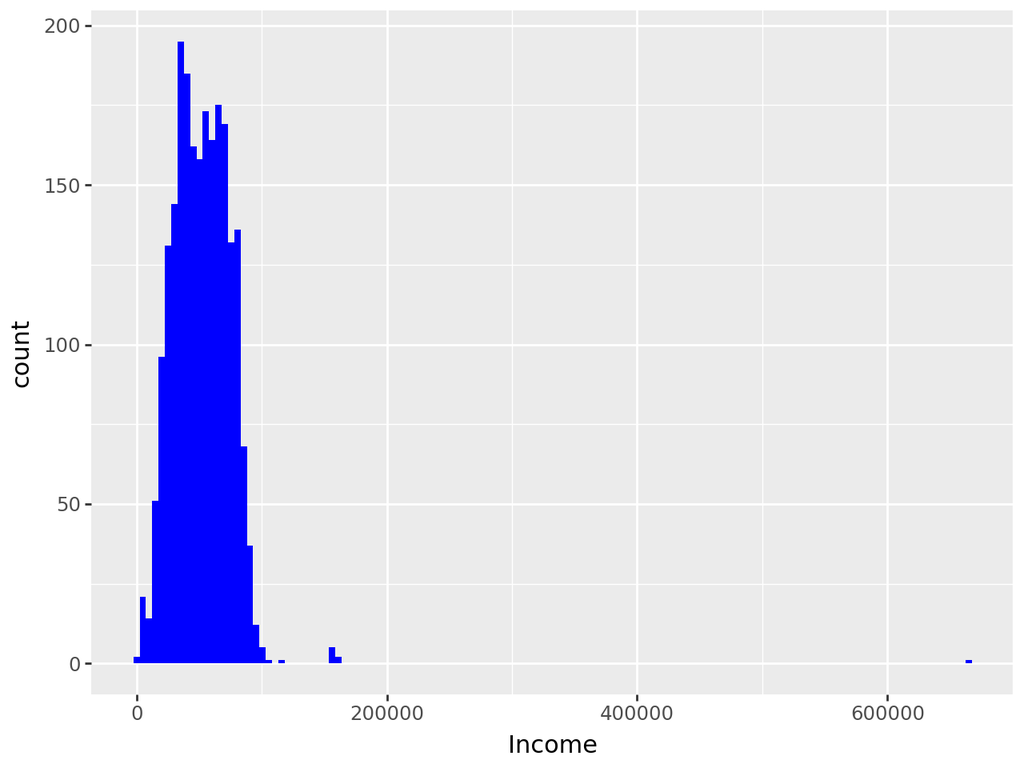

```python
(ggplot(df, aes(x = "Income")) +
    geom_histogram(fill = "blue"))
```

The datapoint around $650,000 seems to be an outlier.

## Identifying Outlier

```python
df[df["Income"] > 600000]
```

|  | Id | Year_Birth | Education | Marital_Status | Income | Kidhome | Teenhome | Dt_Customer | Recency | MntWines | MntFruits | MntMeatProducts | MntFishProducts | MntSweetProducts | MntGoldProds | NumDealsPurchases | NumWebPurchases | NumCatalogPurchases | NumStorePurchases | NumWebVisitsMonth | Response | Complain | Age | Days_Customer |
| --- | --- | --- | --- | --- | --- | --- | --- | --- | --- | --- | --- | --- | --- | --- | --- | --- | --- | --- | --- | --- | --- | --- | --- | --- |
| 527 | 9432 | 1977 | Graduation | Together | 666666.0 | 1 | 0 | 2013-02-06 | 23 | 9 | 14 | 18 | 8 | 1 | 12 | 4 | 3 | 1 | 3 | 6 | 0 | 0 | 47 | 4262 |

## Histogram without Outlier

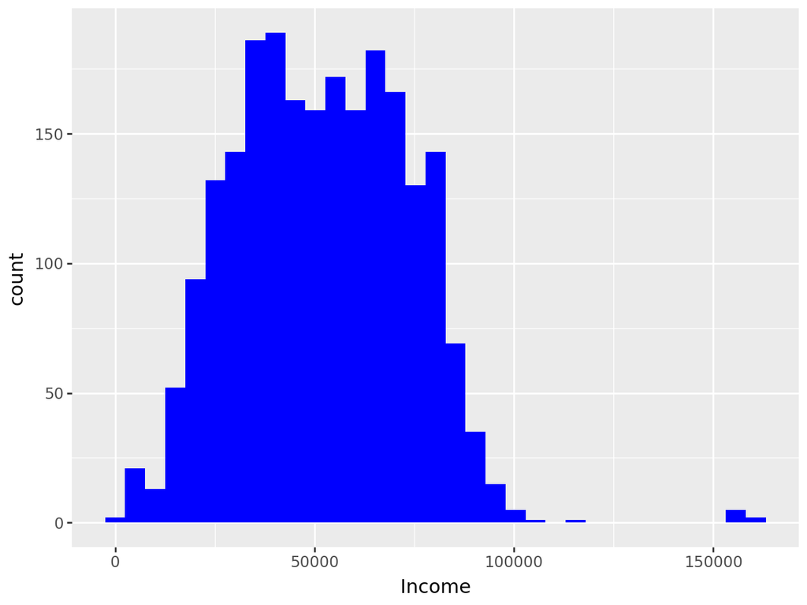

```python
df = df[df["Income"] < 600000]
(ggplot(df, aes(x = "Income")) +
    geom_histogram(fill = "blue"))
```

The Distribution is more condensed without the $666,666 value, but there are still some outliers remaining. I will use the mean + 1.5IQR rule to eliminate additional outliers.

```python
print(f"Mean Income = {round(df["Income"].mean())}")

q1 = df["Income"].quantile(0.25)
q3 = df["Income"].quantile(0.75)
IQR = q3 - q1

print(f"Mean + 1.5IQR = {round(df["Income"].mean() + 1.5*IQR)}")
print(f"Mean - 1.5IQR = {round(df["Income"].mean() - 1.5*IQR)}")
```

```
Mean Income = 51978
Mean + 1.5IQR = 101094
Mean - 1.5IQR = 2862
Mean Income = 51978
Mean + 1.5IQR = 101094
Mean - 1.5IQR = 2862
```

## Subsetting Data Excluding Outliers

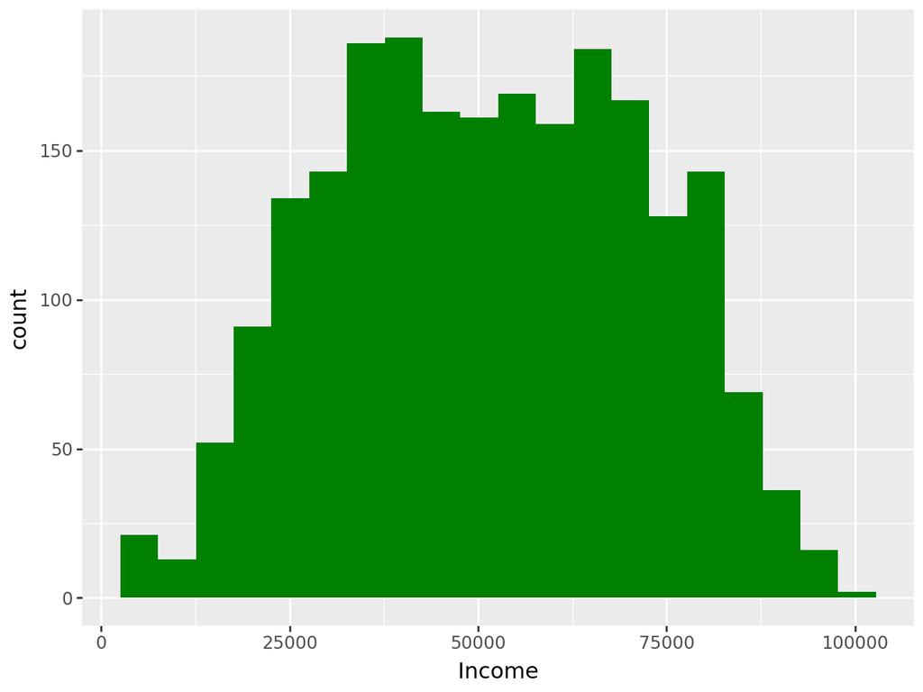

```python
df = df[(df["Income"] < 101094) & (df["Income"] > 2862)]

(ggplot(df, aes(x = "Income")) +
    geom_histogram(fill = "green"))
```

## Visualizing Purchasing Patterns

```python
variables = ['MntWines', 'MntFruits', 'MntMeatProducts', 'MntFishProducts', 'MntSweetProducts', 'MntGoldProds']

spending_df = pd.DataFrame(round(df[variables].mean(), 2))
spending_df = spending_df.reset_index()
spending_df.columns = ["Variable", "Mean"]
spending_df.sort_values(by = "Mean", ascending = False, inplace= True)
spending_df = spending_df.reset_index(drop = True)
spending_df
```

|  | Variable | Mean |
| --- | --- | --- |
| 0 | MntWines | 304.7 |
| 1 | MntMeatProducts | 164.7 |
| 2 | MntGoldProds | 44.0 |
| 3 | MntFishProducts | 37.6 |
| 4 | MntSweetProducts | 26.9 |
| 5 | MntFruits | 26.3 |

From this table, it is clear that Wine brings in the most revenue for Gerry’s Grocery Store. Meat is the next most revenue while Gold, Fish, Sweets and Fruits rank closely towards the bottom.

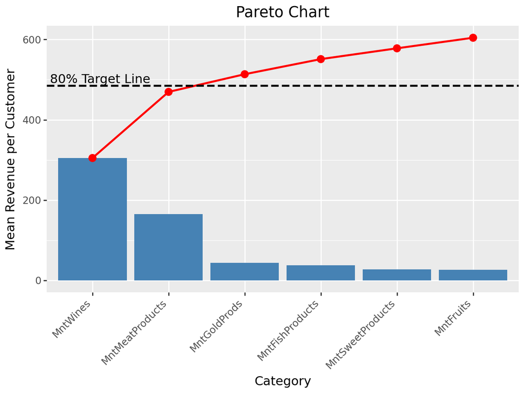

```python
from plotnine import ggplot, aes, geom_bar, geom_line, geom_point, scale_y_continuous, labs, theme, element_text, geom_hline, annotate

spending_df["Cumulative"] = spending_df["Mean"].cumsum()
spending_df["Percentage"] = spending_df["Cumulative"] / spending_df["Mean"].sum() * 100

spending_df['Variable'] = pd.Categorical(spending_df['Variable'],
                                           categories=spending_df['Variable'],
                                           ordered=True)

(ggplot(spending_df, aes(x='Variable', y='Mean')) +
    geom_bar(stat='identity', fill='steelblue') +
    geom_line(aes(y='Cumulative', group=1), color='red', size=1) +
    geom_hline(yintercept=484.84, linetype='dashed', color='black', size=1) +
    annotate("text", x=1.1, y=500, label="80% Target Line", color="black", ha="center") +
    geom_point(aes(y='Cumulative'), color='red', size=3) +

    labs(title='Pareto Chart',
         x='Category',
         y='Mean Revenue per Customer') +
    theme(axis_text_x=element_text(rotation=45, hjust=1))
)
```

From this pareto chart, we can see that Wine and Meat make up about 80% of Gerry’s Grocery Store’s total revenue while only accounting for 33% of the product selection. Therefore, Wine and Meat should be the main priority and customers with high spending tendencies for those 2 categories are the most valuable. Gerry’s Grocery Store reflects the 80/20 rule in business.

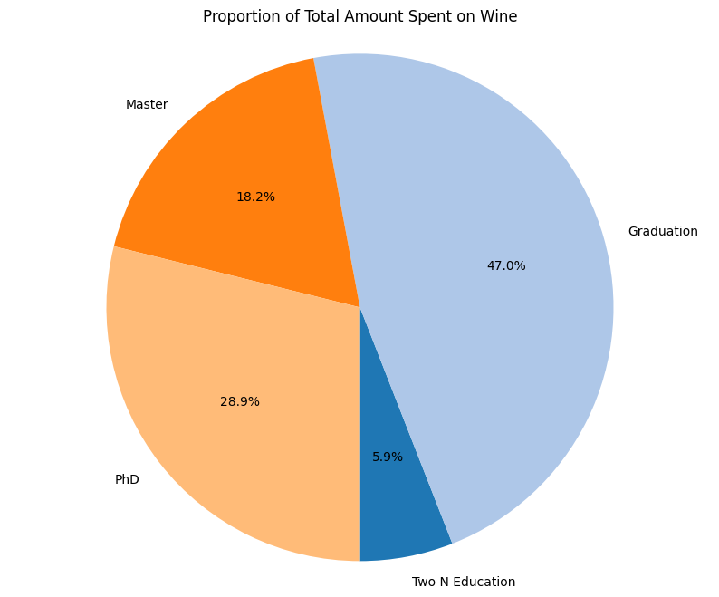

```python
wine_spending = df.groupby('Education', as_index=False)['MntWines'].sum()
wine_spending = wine_spending[wine_spending['Education'] != 'Basic']


wine_spending["Education"].replace('2n Cycle', 'Two N Education', inplace= True)

import matplotlib.pyplot as plt

plt.clf()
plt.figure(figsize=(10, 8))
plt.pie(wine_spending['MntWines'], labels=wine_spending['Education'], autopct='%1.1f%%', startangle=270, colors=plt.cm.tab20.colors)
plt.axis('equal')  # Equal aspect ratio ensures that pie chart is circular.
plt.title('Proportion of Total Amount Spent on Wine')
plt.show()
```

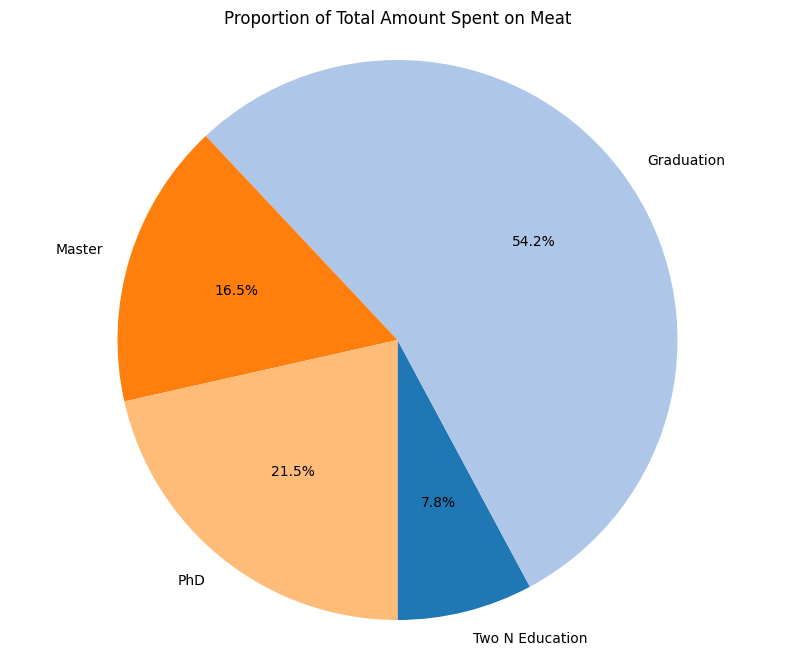

```python
meat_spending = df.groupby('Education', as_index=False)['MntMeatProducts'].sum()
meat_spending = meat_spending[meat_spending['Education'] != 'Basic']

meat_spending["Education"].replace('2n Cycle', 'Two N Education', inplace = True)

plt.clf()
plt.figure(figsize=(10, 8))
plt.pie(meat_spending['MntMeatProducts'], labels=meat_spending['Education'], autopct='%1.1f%%', startangle=270, colors=plt.cm.tab20.colors)
plt.axis('equal')  # Equal aspect ratio ensures that pie chart is circular.
plt.title('Proportion of Total Amount Spent on Meat')
plt.show()
```

From these 2 pie charts, we can see that almost half of revenue from meat and wine come from the “College Graduate” level. However, this does not tell the full story. The “Basic” education level was excluded because it accounted for less than 1% of the total revenue

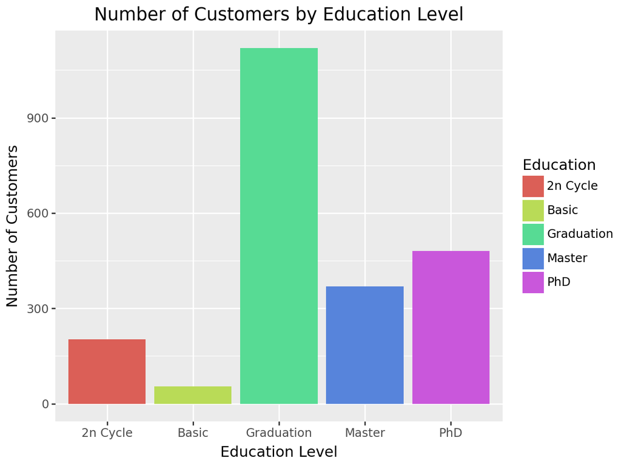

```python
(ggplot(df, aes(x = "Education", fill = "Education"))
    + geom_bar()
    + labs(title = "Number of Customers by Education Level",
           y = "Number of Customers",
           x = "Education Level"))
```

Although College Graduates account for the most revenue from wine and meat, they also account for nearly 50% of the entire customer population.

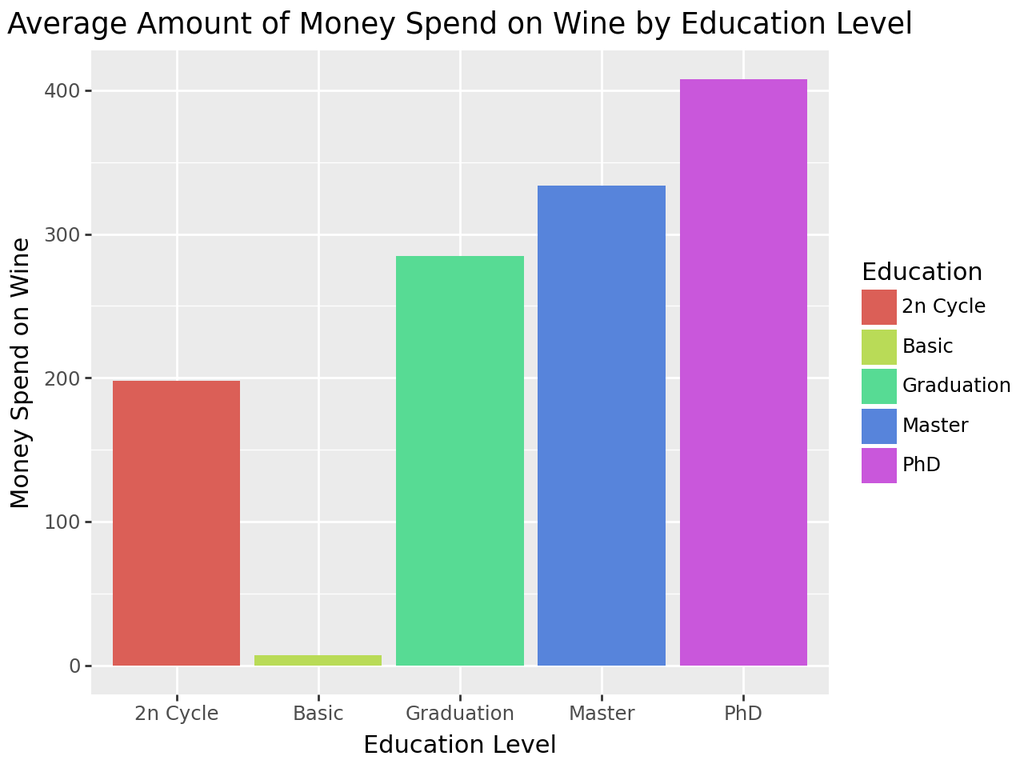

```python
from plotnine import geom_bar, labs

(ggplot(df, aes(x = "Education", y = "MntWines", fill = "Education"))
    + geom_bar(stat = "summary")
    + labs(title = "Average Amount of Money Spend on Wine by Education Level",
           y = "Money Spend on Wine",
           x = "Education Level"))
```

Taking a look at average amount spent on wine between each education level, we can see that as education level increases, so does amount spent on wine. This could be attributed to higher annual income for more advanced degrees. Nonetheless, Gerry’s Grocery Store should try to target people with Masters or PhD’s when promoting wine. This can come in the form of coupons to incentivize additional wine purchasing from these customers.

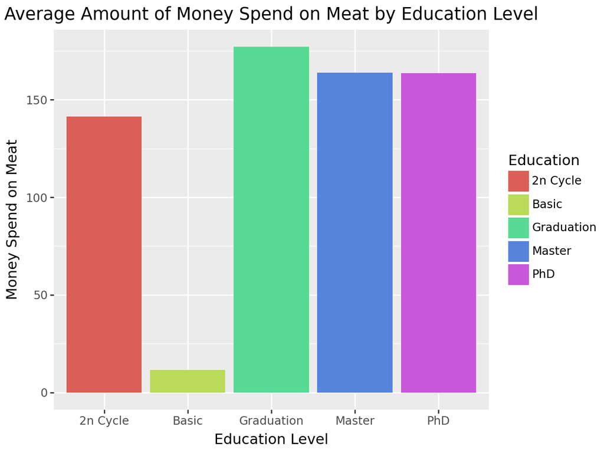

```python
from plotnine import geom_bar, labs

(ggplot(df, aes(x = "Education", y = "MntMeatProducts", fill = "Education"))
    + geom_bar(stat = "summary")
    + labs(title = "Average Amount of Money Spend on Meat by Education Level",
           y = "Money Spend on Meat",
           x = "Education Level"))
```

The average spending on meat products was more balanced. However, the College Graduate level was the highest on average.

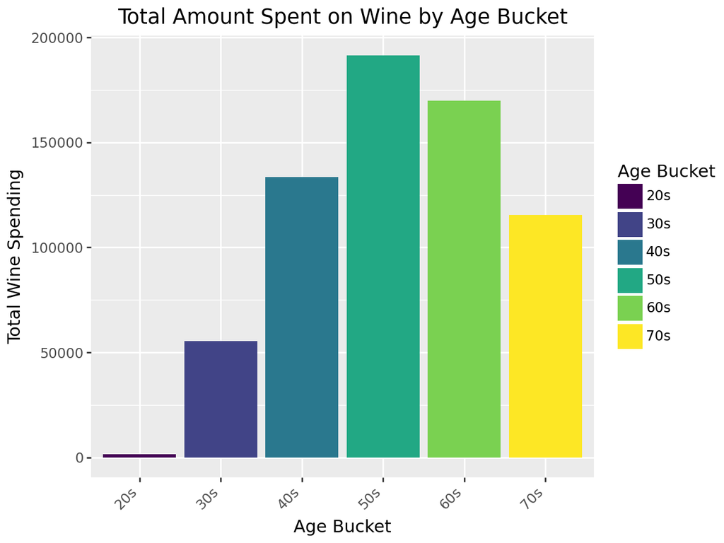

```python
bins = [20, 30, 40, 50, 60, 70, 80]  # Define the bin edges
labels = ['20s', '30s', '40s', '50s', '60s', '70s']  # Define the labels for each bucket
df['Age Bucket'] = pd.cut(df['Age'], bins=bins, labels=labels, right=False)

# Group by age buckets and sum MntWines
grouped_data = df.groupby('Age Bucket', as_index=False)['MntWines'].sum()

# Create the bar chart
(ggplot(grouped_data, aes(x='Age Bucket', y='MntWines', fill = "Age Bucket")) +  # Set x and y aesthetics
    geom_bar(stat='identity') +  # Use stat='identity' to represent actual values
    labs(title='Total Amount Spent on Wine by Age Bucket',
         x='Age Bucket',
         y='Total Wine Spending') +  # Set labels
    theme(axis_text_x=element_text(rotation=45, hjust=1))  # Rotate x-axis labels for readability
)
```

Gerry’s largest wine revenue source is people in their 50s and 60s. This is expected becasue older people enjoy wine moreso than younger people. The reason for the staggeringly low wine spending from 20s customers is because they were severely underrepresented in our dataset.

# Linear Regression Model for Inference

## Predicting Amount Spent on Wine

```python
df.head()
```

|  | Id | Year_Birth | Education | Marital_Status | Income | Kidhome | Teenhome | Dt_Customer | Recency | MntWines | MntFruits | MntMeatProducts | MntFishProducts | MntSweetProducts | MntGoldProds | NumDealsPurchases | NumWebPurchases | NumCatalogPurchases | NumStorePurchases | NumWebVisitsMonth | Response | Complain | Age | Days_Customer | Age Bucket |
| --- | --- | --- | --- | --- | --- | --- | --- | --- | --- | --- | --- | --- | --- | --- | --- | --- | --- | --- | --- | --- | --- | --- | --- | --- | --- |
| 0 | 1826 | 1970 | Graduation | Divorced | 84835.0 | 0 | 0 | 2014-06-16 | 0 | 189 | 104 | 379 | 111 | 189 | 218 | 1 | 4 | 4 | 6 | 1 | 1 | 0 | 54 | 3767 | 50s |
| 1 | 1 | 1961 | Graduation | Single | 57091.0 | 0 | 0 | 2014-06-15 | 0 | 464 | 5 | 64 | 7 | 0 | 37 | 1 | 7 | 3 | 7 | 5 | 1 | 0 | 63 | 3768 | 60s |
| 2 | 10476 | 1958 | Graduation | Married | 67267.0 | 0 | 1 | 2014-05-13 | 0 | 134 | 11 | 59 | 15 | 2 | 30 | 1 | 3 | 2 | 5 | 2 | 0 | 0 | 66 | 3801 | 60s |
| 3 | 1386 | 1967 | Graduation | Together | 32474.0 | 1 | 1 | 2014-11-05 | 0 | 10 | 0 | 1 | 0 | 0 | 0 | 1 | 1 | 0 | 2 | 7 | 0 | 0 | 57 | 3625 | 50s |
| 4 | 5371 | 1989 | Graduation | Single | 21474.0 | 1 | 0 | 2014-08-04 | 0 | 6 | 16 | 24 | 11 | 0 | 34 | 2 | 3 | 1 | 2 | 7 | 1 | 0 | 35 | 3718 | 30s |

```python
df["Education"].value_counts()
```

```
Education
Graduation    1119
PhD            480
Master         369
2n Cycle       203
Basic           54
Name: count, dtype: int64
```

```python
df["Marital_Status"].value_counts()
```

```
Marital_Status
Married     853
Together    573
Single      474
Divorced    225
Widow        74
Alone         3
YOLO          2
Absurd        2
Name: count, dtype: int64
```

```python
from sklearn.linear_model import LinearRegression
from sklearn.model_selection import train_test_split
from sklearn.metrics import mean_squared_error, r2_score

df = df.dropna()

df_with_dummies = pd.get_dummies(df, columns=["Education", "Marital_Status"], drop_first=True)
dummy_cols = df_with_dummies.columns[df_with_dummies.columns.str.startswith(('Education_', 'Marital_Status_'))]
df_with_dummies[dummy_cols] = df_with_dummies[dummy_cols].astype(int)
df_with_dummies = df_with_dummies.drop(columns=['Dt_Customer', 'Age Bucket', "Id"])

x_vars_wine = ["Age", "Kidhome", "Teenhome", 'Recency', 'MntFruits', 'MntMeatProducts',
       'MntFishProducts', 'MntSweetProducts', 'MntGoldProds',
       'NumDealsPurchases', 'NumWebPurchases', 'NumCatalogPurchases',
       'NumStorePurchases', 'NumWebVisitsMonth', 'Response', 'Complain', 'Age',
       'Days_Customer', 'Education_Basic', 'Education_Graduation',
       'Education_Master', 'Education_PhD', 'Marital_Status_Alone',
       'Marital_Status_Divorced', 'Marital_Status_Married',
       'Marital_Status_Single', 'Marital_Status_Together',
       'Marital_Status_Widow', 'Marital_Status_YOLO']

x_wine = df_with_dummies[x_vars_wine]
y_wine = df["MntWines"]

lin_reg_wine = LinearRegression()
lin_reg_wine.fit(x_wine, y_wine)
```

```
LinearRegression()
```

```python
# Display results

print(f"Y Intercept: {round(lin_reg_wine.intercept_, 4)} \n")
pd.DataFrame({'Predictor': x_wine.columns, 'Coefficient': np.round(lin_reg_wine.coef_ ,1)})
```

```
Y Intercept: -488.5396

Y Intercept: -488.5396
```

|  | Predictor | Coefficient |
| --- | --- | --- |
| 0 | Age | 0.0 |
| 1 | Kidhome | -44.4 |
| 2 | Teenhome | 19.4 |
| 3 | Recency | 0.2 |
| 4 | MntFruits | -0.4 |
| 5 | MntMeatProducts | 0.3 |
| 6 | MntFishProducts | -0.3 |
| 7 | MntSweetProducts | -0.3 |
| 8 | MntGoldProds | 0.1 |
| 9 | NumDealsPurchases | -7.7 |
| 10 | NumWebPurchases | 21.3 |
| 11 | NumCatalogPurchases | 44.2 |
| 12 | NumStorePurchases | 30.4 |
| 13 | NumWebVisitsMonth | 15.1 |
| 14 | Response | 78.2 |
| 15 | Complain | -77.1 |
| 16 | Age | 0.0 |
| 17 | Days_Customer | 0.0 |
| 18 | Education_Basic | 26.7 |
| 19 | Education_Graduation | 38.1 |
| 20 | Education_Master | 84.2 |
| 21 | Education_PhD | 122.4 |
| 22 | Marital_Status_Alone | 151.4 |
| 23 | Marital_Status_Divorced | 145.8 |
| 24 | Marital_Status_Married | 133.5 |
| 25 | Marital_Status_Single | 120.4 |
| 26 | Marital_Status_Together | 140.3 |
| 27 | Marital_Status_Widow | 117.0 |
| 28 | Marital_Status_YOLO | 30.4 |

From the Linear Regression of Wine Spending. We can see which factors increase or decrease wine spending. There is a notable difference between parents with younger children vs. teenage children. The younger a parent’s children are, the less they are spending on wine. This makes sense because younger children require more supervision and parents do not have as much time to lounge around and enjoy a glass of wine. It is key for Gus to avoid targeting parents with young children in order to maximize promotion gains.

## Predicting Amount Spent on Meat

```python
x_vars_meat = ["Age", "Kidhome", "Teenhome", 'Recency', 'MntFruits', 'MntWines',
       'MntFishProducts', 'MntSweetProducts', 'MntGoldProds',
       'NumDealsPurchases', 'NumWebPurchases', 'NumCatalogPurchases',
       'NumStorePurchases', 'NumWebVisitsMonth', 'Response', 'Complain', 'Age',
       'Days_Customer', 'Education_Basic', 'Education_Graduation',
       'Education_Master', 'Education_PhD', 'Marital_Status_Alone',
       'Marital_Status_Divorced', 'Marital_Status_Married',
       'Marital_Status_Single', 'Marital_Status_Together',
       'Marital_Status_Widow', 'Marital_Status_YOLO']

x_meat = df_with_dummies[x_vars_meat]
y_meat = df["MntMeatProducts"]

lin_reg_meat = LinearRegression()
lin_reg_meat.fit(x_meat, y_meat)
```

```
LinearRegression()
```

```python
# Display results

print(f"Y Intercept: {round(lin_reg_meat.intercept_, 4)} \n")
pd.DataFrame({'Predictor': x_meat.columns, 'Coefficient': np.round(lin_reg_meat.coef_ ,1)})
```

```
Y Intercept: -201.0103

Y Intercept: -201.0103
```

|  | Predictor | Coefficient |
| --- | --- | --- |
| 0 | Age | 0.0 |
| 1 | Kidhome | -2.0 |
| 2 | Teenhome | -56.8 |
| 3 | Recency | 0.2 |
| 4 | MntFruits | 0.7 |
| 5 | MntWines | 0.1 |
| 6 | MntFishProducts | 0.6 |
| 7 | MntSweetProducts | 0.5 |
| 8 | MntGoldProds | -0.1 |
| 9 | NumDealsPurchases | -2.6 |
| 10 | NumWebPurchases | 1.0 |
| 11 | NumCatalogPurchases | 16.7 |
| 12 | NumStorePurchases | 2.0 |
| 13 | NumWebVisitsMonth | -16.7 |
| 14 | Response | 57.0 |
| 15 | Complain | -1.7 |
| 16 | Age | 0.0 |
| 17 | Days_Customer | 0.0 |
| 18 | Education_Basic | -26.2 |
| 19 | Education_Graduation | 21.8 |
| 20 | Education_Master | 20.3 |
| 21 | Education_PhD | 11.0 |
| 22 | Marital_Status_Alone | 154.9 |
| 23 | Marital_Status_Divorced | 158.6 |
| 24 | Marital_Status_Married | 168.1 |
| 25 | Marital_Status_Single | 182.2 |
| 26 | Marital_Status_Together | 175.3 |
| 27 | Marital_Status_Widow | 153.6 |
| 28 | Marital_Status_YOLO | 187.3 |

This output for Meat Spending linear regression reveals some interesting insight. One point of emphasis is the relationship between Number of Catalog purchases and Meat Spending. It appears that the more times a customer purchases from the catalog, the more they are spending on meat. Gerry’s Grocery Store can use this information by continuously advertising meat in the store’s weekly catalog

# Spotlight Analysis

```python
# X Y relationshpi between NUmCatalog, NumWeb, etc. and (Mnt Wines and MntMeatProducts)

df.head()
```

|  | Id | Year_Birth | Education | Marital_Status | Income | Kidhome | Teenhome | Dt_Customer | Recency | MntWines | MntFruits | MntMeatProducts | MntFishProducts | MntSweetProducts | MntGoldProds | NumDealsPurchases | NumWebPurchases | NumCatalogPurchases | NumStorePurchases | NumWebVisitsMonth | Response | Complain | Age | Days_Customer | Age Bucket |
| --- | --- | --- | --- | --- | --- | --- | --- | --- | --- | --- | --- | --- | --- | --- | --- | --- | --- | --- | --- | --- | --- | --- | --- | --- | --- |
| 0 | 1826 | 1970 | Graduation | Divorced | 84835.0 | 0 | 0 | 2014-06-16 | 0 | 189 | 104 | 379 | 111 | 189 | 218 | 1 | 4 | 4 | 6 | 1 | 1 | 0 | 54 | 3767 | 50s |
| 1 | 1 | 1961 | Graduation | Single | 57091.0 | 0 | 0 | 2014-06-15 | 0 | 464 | 5 | 64 | 7 | 0 | 37 | 1 | 7 | 3 | 7 | 5 | 1 | 0 | 63 | 3768 | 60s |
| 2 | 10476 | 1958 | Graduation | Married | 67267.0 | 0 | 1 | 2014-05-13 | 0 | 134 | 11 | 59 | 15 | 2 | 30 | 1 | 3 | 2 | 5 | 2 | 0 | 0 | 66 | 3801 | 60s |
| 3 | 1386 | 1967 | Graduation | Together | 32474.0 | 1 | 1 | 2014-11-05 | 0 | 10 | 0 | 1 | 0 | 0 | 0 | 1 | 1 | 0 | 2 | 7 | 0 | 0 | 57 | 3625 | 50s |
| 4 | 5371 | 1989 | Graduation | Single | 21474.0 | 1 | 0 | 2014-08-04 | 0 | 6 | 16 | 24 | 11 | 0 | 34 | 2 | 3 | 1 | 2 | 7 | 1 | 0 | 35 | 3718 | 30s |

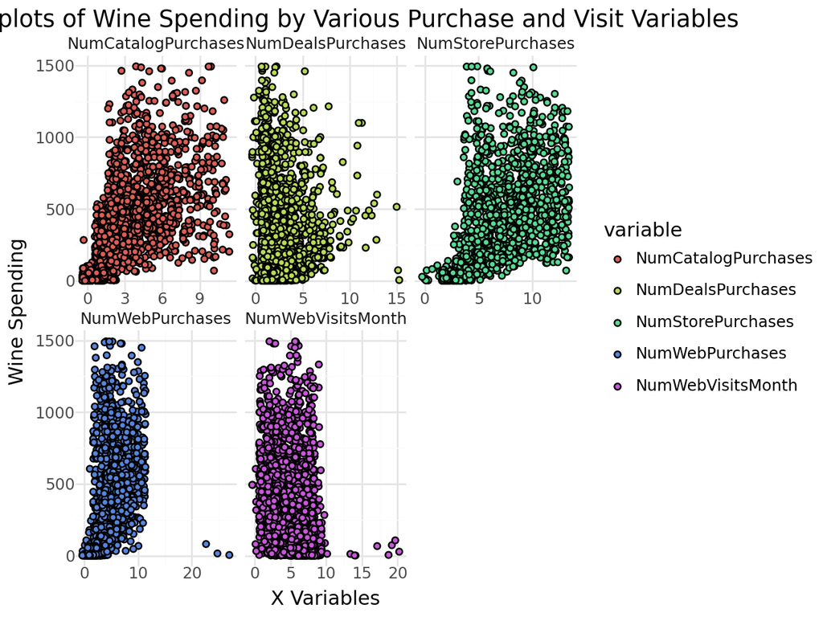

```python
from plotnine import ggplot, aes, geom_jitter, facet_wrap, labs, theme_minimal

# To reshape the data for faceting
df_melted = pd.melt(df,
                    id_vars=['MntWines'],
                    value_vars=['NumDealsPurchases', 'NumWebPurchases',
                                'NumCatalogPurchases', 'NumStorePurchases',
                                'NumWebVisitsMonth'])

(ggplot(df_melted, aes(x='value', y='MntWines', fill = "variable"))
    + geom_jitter()
    + facet_wrap('variable', scales='free_x')
    + labs(title='Scatterplots of Wine Spending by Various Purchase and Visit Variables',
           x='X Variables', y='Wine Spending')
    + theme_minimal()
)
```

There seems to be a linear relationship between number of catalog purchases and Wine Spending. Perhaps it is worth placing more wine options in the catalogs.

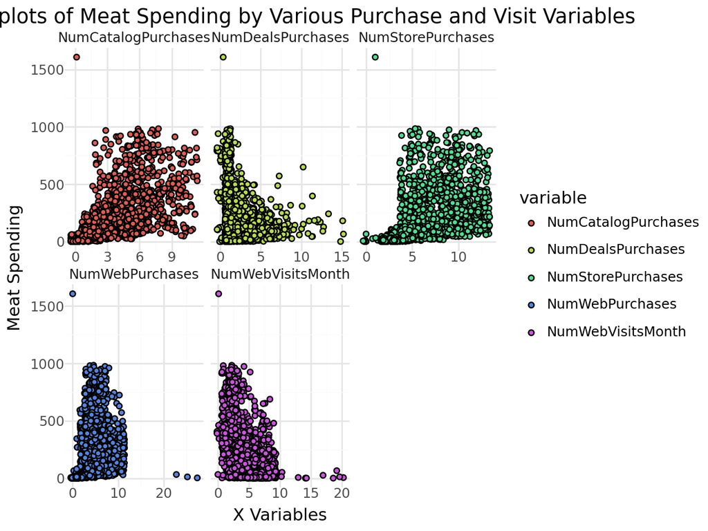

```python
df_melted = pd.melt(df,
                    id_vars=['MntMeatProducts'],
                    value_vars=['NumDealsPurchases', 'NumWebPurchases',
                                'NumCatalogPurchases', 'NumStorePurchases',
                                'NumWebVisitsMonth'])

(ggplot(df_melted, aes(x='value', y='MntMeatProducts', fill = "variable"))
    + geom_jitter()
    + facet_wrap('variable', scales='free_x')
    + labs(title='Scatterplots of Meat Spending by Various Purchase and Visit Variables',
           x='X Variables', y='Meat Spending')
    + theme_minimal()
)
```

An interesting insight from these relationships is that customers who frequently purchase products with deals tend to spend significantly less on Meat than customers capitalizing on a lower amount of deals. The biggest spenders on meat are not using any deals. This may be a cause of correlation, but perhaps placing deals on meat is not necessary.

In this next section, I will shine light on the relationships between certain variables and wine + meat spending. I will show how higher, lower, or average levels of one variable affect the relationship between another variable and wine + meat spending.

## Spotlight 1: Age as a moderator of Number of Catalog Purchases’ Affect on Meat Spending

```python
import statsmodels.formula.api as smf

df["cAge"] = df["Age"] - df["Age"].mean()
df["low_age"] = df["cAge"] + df["Age"].std()

df["cNumCatalogPurchases"] = df["NumCatalogPurchases"] - df["NumCatalogPurchases"].mean()

spotlight = smf.ols('MntMeatProducts ~ low_age * cNumCatalogPurchases', data = df).fit()
print(spotlight.summary())
```

```
                            OLS Regression Results
==============================================================================
Dep. Variable:        MntMeatProducts   R-squared:                       0.496
Model:                            OLS   Adj. R-squared:                  0.495
Method:                 Least Squares   F-statistic:                     722.5
Date:                Tue, 08 Oct 2024   Prob (F-statistic):               0.00
Time:                        15:17:16   Log-Likelihood:                -14239.
No. Observations:                2206   AIC:                         2.849e+04
Df Residuals:                    2202   BIC:                         2.851e+04
Df Model:                           3
Covariance Type:            nonrobust
================================================================================================
                                   coef    std err          t      P>|t|      [0.025      0.975]
------------------------------------------------------------------------------------------------
Intercept                      178.1392      4.660     38.226      0.000     169.000     187.278
low_age                         -1.1135      0.288     -3.864      0.000      -1.679      -0.548
cNumCatalogPurchases            60.7116      1.690     35.915      0.000      57.397      64.027
low_age:cNumCatalogPurchases    -0.3656      0.099     -3.707      0.000      -0.559      -0.172
==============================================================================
Omnibus:                      932.700   Durbin-Watson:                   1.853
Prob(Omnibus):                  0.000   Jarque-Bera (JB):             8705.816
Skew:                           1.741   Prob(JB):                         0.00
Kurtosis:                      12.088   Cond. No.                         67.2
==============================================================================

Notes:
[1] Standard Errors assume that the covariance matrix of the errors is correctly specified.
                            OLS Regression Results
==============================================================================
Dep. Variable:        MntMeatProducts   R-squared:                       0.496
Model:                            OLS   Adj. R-squared:                  0.495
Method:                 Least Squares   F-statistic:                     722.5
Date:                Tue, 08 Oct 2024   Prob (F-statistic):               0.00
Time:                        15:17:16   Log-Likelihood:                -14239.
No. Observations:                2206   AIC:                         2.849e+04
Df Residuals:                    2202   BIC:                         2.851e+04
Df Model:                           3
Covariance Type:            nonrobust
================================================================================================
                                   coef    std err          t      P>|t|      [0.025      0.975]
------------------------------------------------------------------------------------------------
Intercept                      178.1392      4.660     38.226      0.000     169.000     187.278
low_age                         -1.1135      0.288     -3.864      0.000      -1.679      -0.548
cNumCatalogPurchases            60.7116      1.690     35.915      0.000      57.397      64.027
low_age:cNumCatalogPurchases    -0.3656      0.099     -3.707      0.000      -0.559      -0.172
==============================================================================
Omnibus:                      932.700   Durbin-Watson:                   1.853
Prob(Omnibus):                  0.000   Jarque-Bera (JB):             8705.816
Skew:                           1.741   Prob(JB):                         0.00
Kurtosis:                      12.088   Cond. No.                         67.2
==============================================================================

Notes:
[1] Standard Errors assume that the covariance matrix of the errors is correctly specified.
```

# Customer Segmentation

## Principal Component Analysis

```
Explained Variance Ratio: [0.19872582 0.08309263]
Explained Variance Ratio: [0.19872582 0.08309263]
```

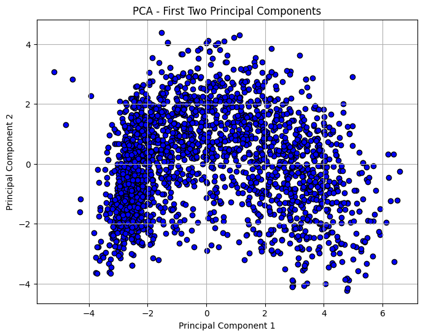

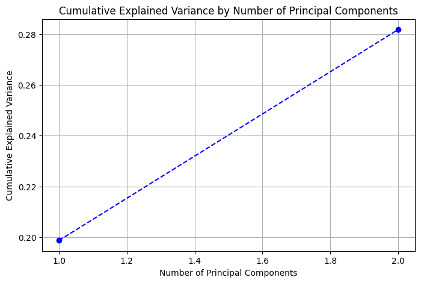

```python
from sklearn.decomposition import PCA
from sklearn.preprocessing import StandardScaler


# Step 1: Standardize the data
scaler = StandardScaler()
scaled_data = scaler.fit_transform(df_with_dummies)

# Step 2: Apply PCA
pca = PCA(n_components=2)  # Choose how many principal components you want
pca_result = pca.fit_transform(scaled_data)

# Step 3: Explained variance ratio
explained_variance = pca.explained_variance_ratio_

# Print the explained variance for each principal component
print(f"Explained Variance Ratio: {explained_variance}")

# Step 4: Visualize the first two principal components
plt.figure(figsize=(8, 6))
plt.scatter(pca_result[:, 0], pca_result[:, 1], c='b', edgecolor='k')
plt.title('PCA - First Two Principal Components')
plt.xlabel('Principal Component 1')
plt.ylabel('Principal Component 2')
plt.grid(True)
plt.show()

# Optional: If you want to see the cumulative explained variance to decide how many components to keep:
cumulative_variance = np.cumsum(pca.explained_variance_ratio_)

plt.figure(figsize=(8, 5))
plt.plot(range(1, len(cumulative_variance) + 1), cumulative_variance, marker='o', linestyle='--', color='b')
plt.title('Cumulative Explained Variance by Number of Principal Components')
plt.xlabel('Number of Principal Components')
plt.ylabel('Cumulative Explained Variance')
plt.grid(True)
plt.show()
```

## K-Means Cluster Analysis

```python
df["PC1"] = pca_result[:, 0]
df["PC2"] = pca_result[:, 1]

kmeans = KMeans(n_clusters=3, random_state=99)

df['Cluster'] = kmeans.fit_predict(df[['PC1', 'PC2']])
df['Cluster'] = df['Cluster'].apply(lambda x: x + 1)
```

```python
var_df = pd.DataFrame(df_with_dummies.var())
var_df = var_df.reset_index()
var_df.columns = ["Variable", "Variance"]

pd.options.display.float_format = '{:.1f}'.format

var_df = var_df.sort_values(by = "Variance", ascending = False)
var_df = var_df.reset_index(drop = True)
var_df.head()
```

|  | Variable | Variance |
| --- | --- | --- |
| 0 | Income | 459352922.5 |
| 1 | Id | 10556396.8 |
| 2 | MntWines | 112695.5 |
| 3 | Days_Customer | 54161.8 |
| 4 | MntMeatProducts | 50838.1 |

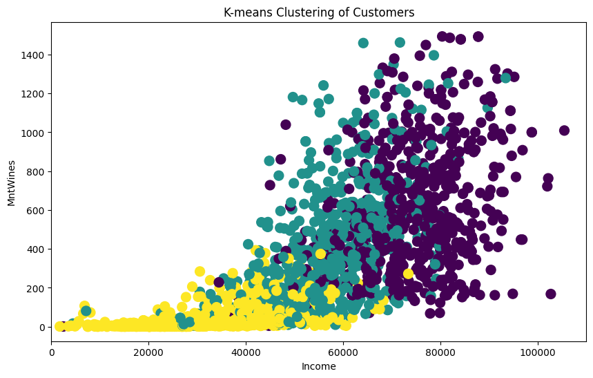

```python
plt.figure(figsize=(10, 6))
plt.scatter(df['Income'], df['MntWines'], c=df['Cluster'], cmap='viridis', s=100)
plt.title('K-means Clustering of Customers')
plt.xlabel('Income')
plt.xlim(0, 110000)
plt.ylabel('MntWines')
plt.show()
```

I chose 3 distinct clusters because Gerry’s Grocery Store would like to implement a Differentiated Targeting approach, where each distinct cluster receives a different marketing mix. Three is the most amount of feasible marketing mixes.

### Understanding Demographics of the 3 Clusters

```python
cluster_means = df.groupby('Cluster')[['Age', 'Income']].mean()
cluster_means = cluster_means.round(2)
cluster_means
```

| Cluster | Age | Income |
| --- | --- | --- |
| 1 | 54.3 | 74464.9 |
| 2 | 63.0 | 55278.2 |
| 3 | 49.2 | 33086.6 |

From a high-level perspective, cluster 1 is wealthy mid 50s customers, cluster 2 is middle-income 60s customers, and cluster 3 is lower-class younger customers

```python
cluster_means = df.groupby('Cluster')[['MntWines', 'MntMeatProducts']].mean()

cluster_means["Total Spending"] = 0.65 * cluster_means["MntWines"] + 0.35 * cluster_means["MntMeatProducts"]
cluster_means = cluster_means.round(2)

cluster_means
```

| Cluster | MntWines | MntMeatProducts | Total Spending |
| --- | --- | --- | --- |
| 1 | 594.9 | 431.5 | 537.7 |
| 2 | 369.3 | 100.2 | 275.1 |
| 3 | 40.7 | 25.7 | 35.4 |

From this table, it is clear that Cluster 1 is the most valuable cluster because they are by far the biggest spenders on both Wines and Meat.

Since Wine accounts for 50% and Meat accounts for 27% of total revenue, I added a column for weighted spending (50/77 % Wine and 27/77 % Meat).

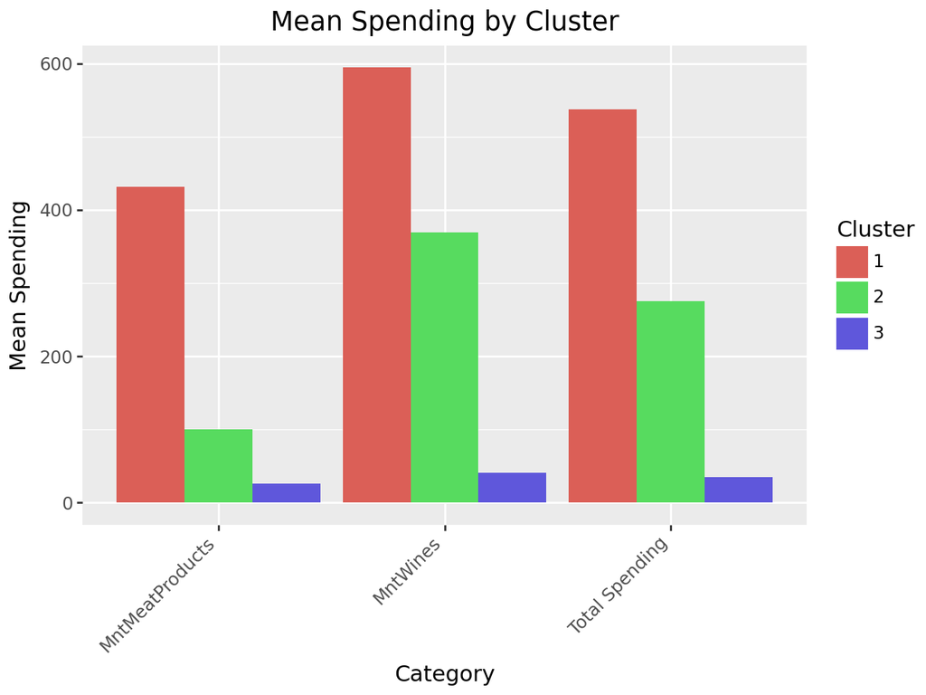

```python
cluster_means = cluster_means.reset_index()
cluster_means_melted = cluster_means.melt(id_vars='Cluster', var_name='Category', value_name='Mean')
cluster_means_melted["Cluster"] = cluster_means_melted["Cluster"].astype("category")

from plotnine import ggplot, aes, geom_col, labs, theme

(ggplot(cluster_means_melted, aes(x='Category', y='Mean', fill='Cluster')) +
    geom_col(position='dodge') +
    labs(title='Mean Spending by Cluster',
         x='Category',
         y='Mean Spending',
         fill='Cluster') +  # Label for the legend
    theme(axis_text_x=element_text(rotation=45, hjust=1))  # Rotate x-axis labels for better visibility
)
```

```python
df_with_dummies["Cluster"] = kmeans.fit_predict(scaled_data)

cluster_means = df_with_dummies.groupby('Cluster')[['Age', 'Education_Basic', 'Education_Graduation', "Education_Master", "Education_PhD"]].mean()

cluster_means["Education_TwoNCycle"] = 1 - (cluster_means['Education_Basic'] + cluster_means['Education_Graduation'] + cluster_means['Education_Master'] + cluster_means['Education_PhD'])
cluster_means = cluster_means.round(2)
cluster_means
```

[output not shown]